# Clean Data and Business Value Proposition

Riley Feltner and Rj Menter

2023-10-03

# Business Value Proposition Graphic

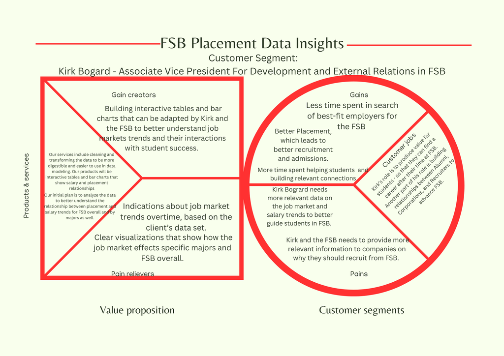

---

# **Group 10 Analytics Class Project**

Our client, Kirk Bogard, is seeking relevant data on the job market and salary trends to better guide the farmer school of business. The question we are answering for Kirk is: What are the macro placement and salary trends we are seeing over the past three years? Our information will aid in providing companies with relevant information on why they should recruit from FSB as well as targeting companies that are good fits for students. The information provided will help students in understanding the current job market and how they can get placed with a company.

We will perform an analysis on the data to better understand the relationship between placement and salary trends for FSB overall and by major over time, using a variety of tools - such as bar charts, interactive tables, and some visualizations to provide different perspectives and to answer our clients question in a meaningful capacity.

## Data History

Annually, the FSB conducts a senior survey of graduates to learn of their employment status. In addition, information is verified using LinkedIn and employer survey information. The data you are provided (‘FSB_BI_Survey_2019_2021.rds’) contains data on graduates for 2019, 2020, and 2021. The data are merged from two sources: the senior survey, and data from the Miami University database.

The data are anonymized, however it is possible that if you look hard enough, you can identify students. You are bound, ethically not to do so.

## Data Dictionary

Attached here is the data dictionary which defines all variables from the data set.

nmajor: numeric,derived, the number of majors

major1: text, OBIEE, first major

major 2: text, OBIEE, second major

BBRJ: binary, OBIEE, an attribute of a student, but we do not know what this stands for

Business Direct Admit: binary, OBIEE, a direct admit to FSB as a first year

Combined Cacc and Masters: binary, OBIEE, combined degree student

Dean’s List: binary, OBIEE, achieve dean’s list status at least once

First Generation College Stdnt: binary, OBIEE, first generation student status

FSB Scholars: binary, OBIEE, FSB scholars program

Honors Program: binary, OBIEE, member of University honors program

President’s list: binary, OBIEE, achieved president’s list at least once

Study Abroud Courtesy Account: binary, OBIEE, do not know meaning

Transfer Work: binary, OBIEE, do not know exact meaning

Cum Laude: binary, OBIEE, graduated Cum Laude

Magna Cum Laude: binary, OBIEE, graduated Magna Cum Laude

Summa Cum Laude: binary, OBIEE, graduated Summa Cum Laude

University Honors: binary, OBIEE, graduated with University Honors

University Honors w/Distinction: binary, OBIEE, graduated with University Honors with Distinction

minor1: text, OBIEE, first listed minor

minor2: text, OBIEE, second listed minor

IPEDS.Race.Ethnicity: text, OBIEE, race/ethnicity

Gender: text, OBIEE, sex

GPA.Range: text, OBIEE, GPA within a .5 range

Term.Code: numberic, OBIEE, First four digits are the physcal year (beginning in July, e.g. July 2020 is FY 2021). Last two digits is the term (10=fall, 15=winter, 20=spring, 30=summer).

Year.x: text, derived, first four digits of Term.Code stored as a character variable

latin_honors: text, survey, latin honors designation

survey_city: text, survey, student reported city in which their job is located

survey_company: text, survey, student reported company in which they accepted a job

survey_deptfunc: text, survey, student reported job function

survey_gradprogram: text, survey, student reported graduate program they will be attending

survey_gradschool: text, survey, stuent reported graduate school they will be attending

survey_internfour: text, survey, student reported fourth internship they held during college

survey_internthree: text, survey, student reported third internship they held during college

survey_interntwo: text, survey, student reported second internship they held during college

survey_internone: text, survey, student reported first internship they held during college

Survey_internships: text, survey, Student reported number of internships they held during college

survey_offers: text, survey, student reported number of offers for full time employment received

survey_plans: text, survey, student reported plans after graduation

survey_pref_field: text, survey, student reported whether working in preferred field

survey_pref_loc: text, survey, student reported whether working in preferred location

survey_salary: numeric, survey, student reported salary

survey_state: text, survey, student reported state in which job is located

### Data Exploration

This first section sets up our knit, our dataframe, and identifies null rows in our data set. We made a secondary dataframe called null rows that can be used for comparison. We also identified many variables with null values: survey_city, survey_company, survey_deptfunc, survey_gradprogram, survey_gradschool, survey_internfour, survey_internone, survey_internships, survey_internthree, survey_interntwo, survey_offers, survey_plans, survey_pref_field, survey_pref_loc, survey_salary, survey_state.

The rest of the variables had the complete sample size of 3235,which was our total number of observations.

---

```r
fsb_data <- readRDS("FSB_BI_Survey_2019_2021.rds")

data_summary <- summary(fsb_data)

sample_sizes <- sapply(fsb_data, function(x) sum(!is.na(x)))
print("Sample Sizes:")
```

```
## [1] "Sample Sizes:"
```

```r
print(sample_sizes)
```

```
##                         nmajor                         major1
##                           3235                           3235
##                         major2                           BBRJ
##                           3235                           3235
##          Business Direct Admit      Combined Bacc and Masters
##                           3235                           3235
##                    Dean's List First Generation College Stdnt
##                           3235                           3235
##                   FSB Scholars                 Honors Program
##                           3235                           3235
##               President's List  Study Abroad Courtesy Account
##                           3235                           3235
##     Transfer Work (Pre-Banner)                      Cum Laude
##                           3235                           3235
##                Magna Cum Laude                Summa Cum Laude
##                           3235                           3235
##              University Honors UniversityHonors w/Distinction
##                           3235                           3235
##                         minor1                         minor2
##                           3235                           3235
##           IPEDS.Race.Ethnicity                         Gender
##                           3235                           3235
##                      GPA.Range                      Term.Code
##                           3235                           3235
##                         year.x                   latin_honors
##                           3235                           3235
##                    survey_city                 survey_company
##                           1920                           1997
##                survey_deptfunc             survey_gradprogram
##                           1496                            188
##              survey_gradschool              survey_internfour
##                            212                            103
##               survey_internone             survey_internships
##                           2258                           2669
##             survey_internthree               survey_interntwo
##                            470                           1365
##                  survey_offers                   survey_plans
##                           2231                           2656
##              survey_pref_field                survey_pref_loc
##                           1685                           1604
##                  survey_salary                   survey_state
##                           1732                           1938
```

```r
total_observations <- nrow(fsb_data)
print(paste("Total Number of Observations:", total_observations))
```

```
## [1] "Total Number of Observations: 3235"
```

```r
null_rows <- fsb_data[!complete.cases(fsb_data), ]
```

```r
sum_of_na_by_variable <- colSums(is.na(fsb_data), na.rm = TRUE)
print(sum_of_na_by_variable)
```

```
##                         nmajor                         major1
##                              0                              0
##                         major2                           BBRJ
##                              0                              0
##          Business Direct Admit      Combined Bacc and Masters
##                              0                              0
##                    Dean's List First Generation College Stdnt
##                              0                              0
##                   FSB Scholars                 Honors Program
##                              0                              0
##               President's List  Study Abroad Courtesy Account
##                              0                              0
##     Transfer Work (Pre-Banner)                      Cum Laude
##                              0                              0
##                Magna Cum Laude                Summa Cum Laude
##                              0                              0
##              University Honors UniversityHonors w/Distinction
##                              0                              0
##                         minor1                         minor2
##                              0                              0
##           IPEDS.Race.Ethnicity                         Gender
##                              0                              0
##                      GPA.Range                      Term.Code
##                              0                              0
##                         year.x                   latin_honors
##                              0                              0
##                    survey_city                 survey_company
##                           1315                           1238
##                survey_deptfunc             survey_gradprogram
##                           1739                           3047
##              survey_gradschool              survey_internfour
##                           3023                           3132
##               survey_internone             survey_internships
##                            977                            566
##             survey_internthree               survey_interntwo
##                           2765                           1870
##                  survey_offers                   survey_plans
##                           1004                            579
##              survey_pref_field                survey_pref_loc
##                           1550                           1631
##                  survey_salary                   survey_state
##                           1503                           1297
```

---

Here is the beginning of our data cleaning analysis, we began by looking at the data dictionary and identified Survey Offers as a variable that should be changed to a numeric variable, and needed to have its values tweaked because the survey responses made the variable hard to analyze otherwise. We identified Survey Offers as a variable that should be changed to numeric, from a categorical type. The following code shows how we identified the unique values that we wanted to change as well as how we resolved non-responses as 0 job offers for that survey response.

---

```r
unique(fsb_data$survey_offers)
```

```
##  [1] NA         "0"        "1"        "4"        "2"        "3"
##  [7] "10"       "6"        "7"        "5"        "na"       "9"
## [13] "8"        "multiple" "2+"
```

```r
# Define a mapping function to change values to NA or a number
map_survey_offers <- function(value) {
  if (is.na(value) || tolower(value) == "na" || value == "multiple" || grepl("\\+", value)) {
    return(NA)
  } else {
    numeric_value <- as.numeric(value)
    if (numeric_value >= 0 && numeric_value <= 10) {
      return(numeric_value)
    } else {
      return(NA)
    }
  }
}

# Apply the mapping function to the survey_offers variable
fsb_data$survey_offers <- sapply(fsb_data$survey_offers, map_survey_offers)

#Replace NA values with 0 in survey_offers
fsb_data$survey_offers[is.na(fsb_data$survey_offers)] <- 0
```

---

To further reduce our dataset we created two dummy variables: has_internship and has_multiple_internships. We then removed the survey_internships, survey_internone, survey_interntwo, survey_internthree, survey_internfour as they are now adding too much complexity to our potential model and are unneeded with the new variables that we have created to represent them.

Below are the steps we took to achieve this: Create a new dummy variable indicating internship presence Create a new dummy variable indicating multiple internships presence Remove the original survey_internships variable because we no longer need it, we have the data from it reflected in two dummy variables. We replaced any of the empty categorical variables from the survey with the text “None” to indicate that the student did not answer.

---

```r
fsb_data$has_internship <- ifelse(is.na(fsb_data$survey_internships) | fsb_data$survey_internships == "0" | fsb_data$survey_internships == "N/A" | fsb_data$survey_internships == "RPT", 0, 1)

fsb_data$has_multiple_internships <- ifelse(is.na(fsb_data$survey_internships) | fsb_data$survey_internships == "0" | fsb_data$survey_internships == "1" | fsb_data$survey_internships == "N/A" | fsb_data$survey_internships == "RPT", 0, 1)

variables_to_drop <- c("survey_internships", "survey_internone", "survey_interntwo", "survey_internthree", "survey_internfour")
fsb_data <- fsb_data[, !(names(fsb_data) %in% variables_to_drop)]
```

```r
fsb_data$survey_deptfunc <- ifelse(is.na(fsb_data$survey_deptfunc), "None", fsb_data$survey_deptfunc)
fsb_data$survey_plans <- ifelse(is.na(fsb_data$survey_plans), "None", fsb_data$survey_plans)
fsb_data$survey_pref_loc <- ifelse(is.na(fsb_data$survey_pref_loc), "None", fsb_data$survey_pref_loc)
fsb_data$survey_pref_field <- ifelse(is.na(fsb_data$survey_pref_field), "None", fsb_data$survey_pref_field)

fsb_data$survey_city <- ifelse(is.na(fsb_data$survey_city), "None", fsb_data$survey_city)
fsb_data$survey_company <- ifelse(is.na(fsb_data$survey_company), "None", fsb_data$survey_company)
fsb_data$survey_gradprogram <- ifelse(is.na(fsb_data$survey_gradprogram), "None", fsb_data$survey_gradprogram)
fsb_data$survey_gradschool <- ifelse(is.na(fsb_data$survey_gradschool), "None", fsb_data$survey_gradschool)
fsb_data$survey_state <- ifelse(is.na(fsb_data$survey_state), "None", fsb_data$survey_state)
```

---

We are making the educated assumption that those who did not report a salary likely did not have a job. Thus, we are imputing the null values with 0 for the numeric field survey_salary.

---

```r
# Observe unique values, and impute null to 0.
unique(fsb_data$survey_salary)
```

```
##   [1]        NA  40000.00  63500.00  68000.00  58000.00  53000.00  85000.00
##   [8]  62000.00  63000.00  50000.00  29000.00  56000.00  55000.00  60000.00
##  [15]  65000.00  45000.00  59000.00  51000.00  54000.00  62500.00  75000.00
##  [22]  90000.00  64500.00  66200.00  82000.00  64000.00  52500.00  67500.00
##  [29]  52000.00  60500.00  61700.00  70000.00  84000.00  35000.00  80000.00
##  [36]  42000.00  67000.00  57000.00  69000.00  72500.00  54900.00  79500.00
##  [43]  44000.00  73000.00  38000.00  57500.00  95000.00  30000.00  90500.00
##  [50]  58300.00  52200.00  58500.00  49920.00  26520.00  66500.00  53500.00
##  [57]  35360.00  72000.00  61000.00  24000.00  71000.00  48000.00  20800.00
##  [64]  66000.00  47000.00  51500.00  64600.00  36000.00 100000.00 175000.00
##  [71]  77000.00  17000.00  41000.00  35600.00  54950.00  56700.00  24960.00
##  [78]  48670.00  50128.00  30160.00  74000.00  41600.00  46000.00  56500.00
##  [85]  77500.00  37000.00  28000.00  39000.00  52250.00  43000.00  32500.00
##  [92]  84480.00  65500.00  55760.00  42500.00  71500.00  34000.00  63800.00
##  [99]  55300.00  25000.00  47840.00  76000.00  55500.00  50500.00  45500.00
## [106]  61500.00  59500.00  92000.00  78000.00  50179.22  31200.00  62700.00
## [113]  49000.00  80500.00  37500.00  52349.00  54500.00  66560.00  61880.00
## [120]  48500.00  60650.00  55737.00  53100.00  68700.00  31000.00  54995.20
## [127]  77750.00  67200.00  59900.00  87000.00  33280.00  88000.00  10000.00
## [134]  73750.00  52800.00  33000.00  58240.00  32000.00  40144.00  43500.00
## [141]  40800.00  55250.00  50960.00  93000.00  42640.00  47010.00  15600.00
## [148]  47500.00  60400.00  67100.00
```

```r
fsb_data$survey_salary[is.na(fsb_data$survey_salary)] <- 0
```

---

We ran the same code that identified our nulls from before, and found that we no longer had any - and had reduced the complexity of the model by removing some unnecessary variables.

---

```r
sum_of_na_by_variable <- colSums(is.na(fsb_data), na.rm = TRUE)
print(sum_of_na_by_variable)
```

```
##                         nmajor                         major1
##                              0                              0
##                         major2                           BBRJ
##                              0                              0
##          Business Direct Admit      Combined Bacc and Masters
##                              0                              0
##                    Dean's List First Generation College Stdnt
##                              0                              0
##                   FSB Scholars                 Honors Program
##                              0                              0
##               President's List  Study Abroad Courtesy Account
##                              0                              0
##     Transfer Work (Pre-Banner)                      Cum Laude
##                              0                              0
##                Magna Cum Laude                Summa Cum Laude
##                              0                              0
##              University Honors UniversityHonors w/Distinction
##                              0                              0
##                         minor1                         minor2
##                              0                              0
##           IPEDS.Race.Ethnicity                         Gender
##                              0                              0
##                      GPA.Range                      Term.Code
##                              0                              0
##                         year.x                   latin_honors
##                              0                              0
##                    survey_city                 survey_company
##                              0                              0
##                survey_deptfunc             survey_gradprogram
##                              0                              0
##              survey_gradschool                  survey_offers
##                              0                              0
##                   survey_plans              survey_pref_field
##                              0                              0
##                survey_pref_loc                  survey_salary
##                              0                              0
##                   survey_state                 has_internship
##                              0                              0
##       has_multiple_internships
##                              0
```

---

Computing Environment - Everything was completed from an R-Project with a working directory set around it. Attached will be a zip folder that contains everything needed to reproduce the work seen here.

---

```r
session_info <- capture.output(sessionInfo())

writeLines(session_info, "computing_environment.txt")

datacleaned <- write.csv(fsb_data, "datacleaned.csv")
```